# rapr: Representative and Adequate Prioritisations in R

## Case-study examples

### Overview

Here we will investigate how space-based targets can affect prioritisations using a more realistic dataset. We will generate prioritisations for the four bird species– [blue-winged kookuburra](http://www.birdlife.org/datazone/speciesfactsheet.php?id=1092&gclid=CjwKEAiApYGyBRC-g_jIstuduV8SJABCEzhZoONUy8VlwRZqeFB1Z5M03CjyneIvX8KdVKIPZvckrRoCgJDw_wcB), [brown-backed honeyeater](http://www.birdlife.org/datazone/species/factsheet/22704394?gclid=CjwKEAiApYGyBRC-g_jIstuduV8SJABCEzhZHxCTcR38YnFlhePYt19gD31lqxxwrMmtIuWFhUwLmRoCGJjw_wcB), [brown falcon](http://www.birdlife.org/datazone/speciesfactsheet.php?id=3588), [pale-headed rosella](http://www.birdlife.org/datazone/speciesfactsheet.php?id=1466)–in Queensland, Australia. This region contains a broad range of different habitats–such as rainforests, woodlands, and deserts–making it ideal for our purposes. First, we will generate a typical amount-based prioritisation that aims to capture 20% of the species’ distributions. Then we will generate a prioritisation that also aims to secure populations in representative parts of the species’ distributions in terms of their geographic location and their environmental heterogeneity. To do this we will generate a prioritisation using 20% amount-based targets and 85% space-based targets. Finally, we will compare these prioritisations to Australia’s existing protected network.

### Data

Survey data for the species were obtained from [BirdLife Australia](http://birdlife.org.au/projects/atlas-and-birdata). The survey data was rarefied using a 100km$^2$ grid, wherein the survey with the greatest number of repeat visits in each grid cell was chosen. To characterise the environmental variation at each survey location (site), [climatic data](http://www.worldclim.org/bioclim) (bio1, bio4, bio15, bio16, bio17) and [classifications of the vegetation at the site](http://www.environment.gov.au/fed/catalog/search/resource/details.page?uuid=%7BEBBCC6FA-8C13-422A-BCD7-24A9F8B52A9A%7D) were obtained. Occupancy-detection models (MacKenzie *et al.* 2002) were fit using Stan [Stan Development Team (2015); with parameters: adapt deta=0.9, maximum treedepth=20, chains=4 , warmup iterations=1000, total iterations=1500] using five-fold cross-validation. In each replicate, data were partitioned into training and test sites. A full model was fit using quadratic terms for environmental variables in the site-component, and an intercept in the detection-component of the model. The full model was then subject to a step-wise backwards term deletion routine. Terms were retained when their inclusion resulted in a model with a greater area under the curve (AUC) value as calculated using the test data. Maps were generated using the best models identifed in each replicate, and then averaging them togeather. To further improve the accuracy of these maps, areas well outside of the species’ known distributions were set to 0. For each species, this was acheived by masking out [biogeographic regions](https://www.environment.gov.au/land/nrs/science/ibra) where the species was not observed, and regions that did not have a neighbor where the species was observed. The maps were then resampled (10km$^2$ resolution) and cropped to the study area. The resulting maps are stored in the `cs_spp` object.

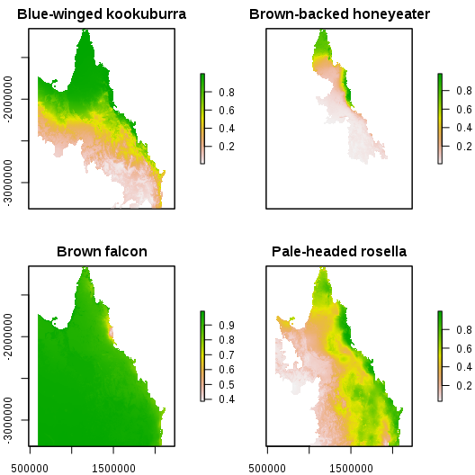

```r
# load data
data(cs_spp)

# plot species' distributions
plot(cs_spp, main=c(
    "Blue-winged kookuburra", "Brown-backed honeyeater",
    "Brown falcon", "Pale-headed rosella"
))
```

Planning units (50km$^2$ resolution) were generated across Australia, and then clipped to the [Queensland state borders and coastline](http://www.abs.gov.au/ausstats/abs@.nsf/mf/1259.0.30.001?OpenDocument). **Note that we are using excessively coarse planning units so that our examples will complete relatively quickly. In a real-world planning exercise, we would use much finer planning units.** To compare our prioritisations to [Queensland’s existing protected area network](http://www.protectedplanet.net/country/AU), this network was intersected with the planning units. Planning units with more than 50% of their area inside a protected area had their status set to 2 ([following conventions in Marxan](http://www.uq.edu.au/marxan/tutorial/module4.html)). Since we do not have cost data, the prioritisations will aim to select the minimum number of planning units required to meet the targets. The planning units are stored in the `cs_pu` object.

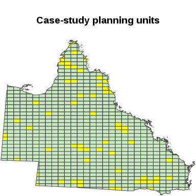

```r
# load data
data(cs_pus)

## plot planning units
# convert SpatialPolygons to PolySet for quick plotting
cs_pus2 <- SpatialPolygons2PolySet(cs_pus)

# create vector of colors for planning units
# + light green: units not already inside reserve
# + yellow: units already inside reserve
cs_pus_cols <- rep('#c7e9c0', nrow(cs_pus@data))
cs_pus_cols[which(cs_pus$status==2)] <- 'yellow'

# set plotting window
par(mar=c(0.1, 0.1, 4.1, 0.1))

# plot polygons
PBSmapping::plotPolys(
    cs_pus2, col=cs_pus_cols, border='gray30',
    xlab='', ylab='', axes=FALSE,
    main='Case-study planning units'
)
```

```r
# reset plotting window
par(mar=c(5.1, 4.1, 4.1, 2.1))
```

To map the distribution of environmental conditions across the species’ range, 21 [bioclimatic layers](http://www.worldclim.org/bioclim) were obtained. These layers were cropped to Australia and subject to [detrended correspondance analysis](http://cc.oulu.fi/~jarioksa/softhelp/vegan/html/decorana.html) to produce two new variables. These layers are stored in the `cs_space` object.

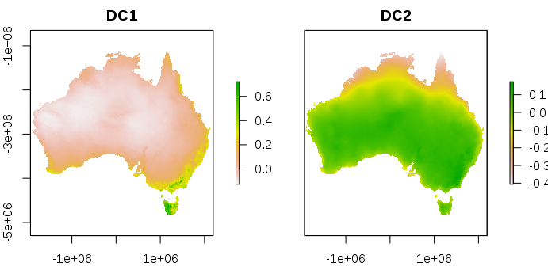

```r
# load data
data(cs_space)

# plot variables
plot(cs_space, main=c('DC1', 'DC2'))
```

### Prioritisations

```r
# make amount-based prioritisation,
# and ignore existing protected areas by discarding values in the
# status (third) column of the attribute table
cs_rs_amount <- rap(
    cs_pus[,-2], cs_spp, cs_space,
  amount.target=0.2, space.target=0, n.demand.points=50L,
  include.geographic.space=TRUE, formulation='unreliable'
)
```

```
## Warning in (function (pus, species, spaces = NULL, amount.target = 0.2, :
## argument to pus does not have a 'status' column, creating default with all
## status=0L
```

```
## Optimize a model with 4 rows, 762 columns and 2267 nonzeros
## Coefficient statistics:
##   Matrix range    [2e+02, 2e+04]
##   Objective range [1e+00, 1e+00]
##   Bounds range    [1e+00, 1e+00]
##   RHS range       [2e+05, 3e+06]
## Found heuristic solution: objective 158
## Presolve time: 0.01s
## Presolved: 4 rows, 762 columns, 2267 nonzeros
## Variable types: 0 continuous, 762 integer (762 binary)
## Presolved: 4 rows, 762 columns, 2267 nonzeros
##
##
## Root relaxation: objective 1.359395e+02, 12 iterations, 0.00 seconds
##
##     Nodes    |    Current Node    |     Objective Bounds      |     Work
##  Expl Unexpl |  Obj  Depth IntInf | Incumbent    BestBd   Gap | It/Node Time
##
##      0     0  135.93952    0    4  158.00000  135.93952  14.0%     -    0s
## H    0     0                     136.0000000  135.93952  0.04%     -    0s
##
## Explored 0 nodes (12 simplex iterations) in 0.02 seconds
## Thread count was 1 (of 2 available processors)
##
## Optimal solution found (tolerance 5.00e-02)
## Best objective 1.360000000000e+02, best bound 1.360000000000e+02, gap 0.0%
```

```r
# show summary
summary(cs_rs_amount)
```

```
##   Run_Number Score Cost Planning_Units Connectivity_Total Connectivity_In
## 1          1   136  136            136           98882414         9686021
##   Connectivity_Edge Connectivity_Out Connectivity_In_Fraction
## 1          81170163          8026230               0.09795494
```

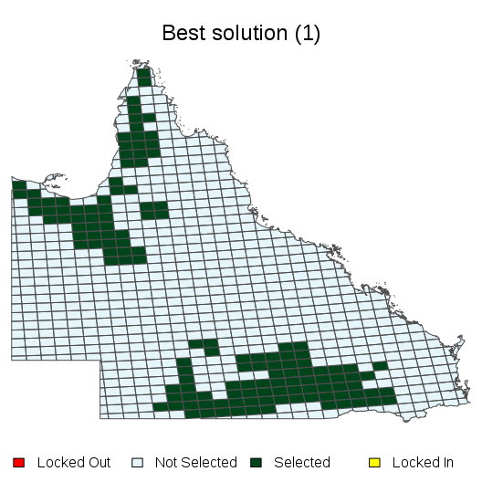

```r
# plot prioritisation
plot(cs_rs_amount, 1)
```

We can also see how well the prioritisation secures the species’ distributions in the geographic and environmental attribute spaces.

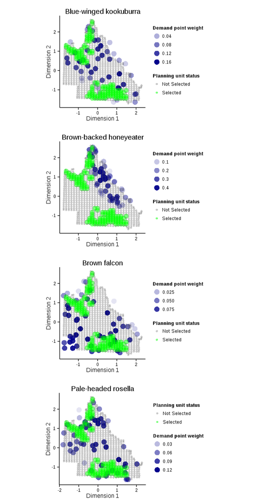

```r
# plot prioritisation in geographic attribute space
p1 <- space.plot(cs_rs_amount, 1, 2, main='Blue-winged kookuburra')
p2 <- space.plot(cs_rs_amount, 2, 2, main='Brown-backed honeyeater')
p3 <- space.plot(cs_rs_amount, 3, 2, main='Brown falcon')
p4 <- space.plot(cs_rs_amount, 4, 2, main='Pale-headed rosella')
gridExtra::grid.arrange(p1, p2, p3, p4, ncol=1)
```

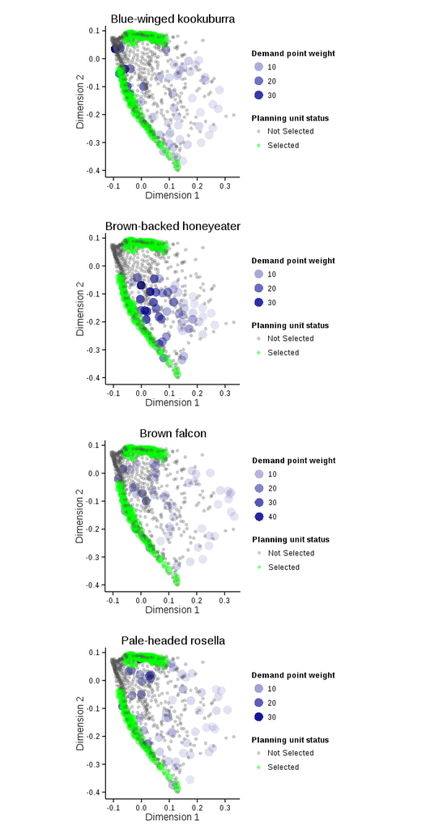

```r
# plot prioritisation in environmental attribute space
p1 <- space.plot(cs_rs_amount, 1, 1, main='Blue-winged kookuburra')
p2 <- space.plot(cs_rs_amount, 2, 1, main='Brown-backed honeyeater')
p3 <- space.plot(cs_rs_amount, 3, 1, main='Brown falcon')
p4 <- space.plot(cs_rs_amount, 4, 1, main='Pale-headed rosella')
gridExtra::grid.arrange(p1, p2, p3, p4, ncol=1)
```

```r
# make amount- and space-based prioritisation
cs_rs_space <- update(cs_rs_amount, space.target=0.85)
```

[output not shown]

[output cut: 19 more lines]

```
## Root relaxation: objective 1.363391e+02, 28892 iterations, 105.82 seconds
## Total elapsed time = 222.44s
## Total elapsed time = 226.06s
##
##     Nodes    |    Current Node    |     Objective Bounds      |     Work
##  Expl Unexpl |  Obj  Depth IntInf | Incumbent    BestBd   Gap | It/Node Time
##
##      0     0  136.33907    0   85          -  136.33907      -     -  227s
## H    0     0                     137.0000000  136.33907  0.48%     -  234s
##
## Explored 0 nodes (31242 simplex iterations) in 234.59 seconds
## Thread count was 1 (of 2 available processors)
##
## Optimal solution found (tolerance 5.00e-02)
## Best objective 1.370000000000e+02, best bound 1.370000000000e+02, gap 0.0%
```

```r
# show summary
summary(cs_rs_space)
```

```
##   Run_Number Score Cost Planning_Units Connectivity_Total Connectivity_In
## 1          1   137  137            137           98882414         6924951
##   Connectivity_Edge Connectivity_Out Connectivity_In_Fraction
## 1          78164299         13793164               0.07003218
```

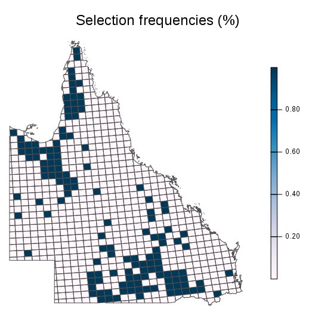

```r
# plot prioritisation
plot(cs_rs_space)
```

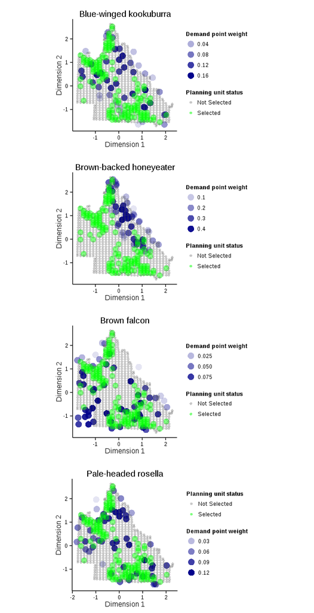

```r
# plot prioritisation in geographic attribute space
p1 <- space.plot(cs_rs_space, 1, 2, main='Blue-winged kookuburra')
p2 <- space.plot(cs_rs_space, 2, 2, main='Brown-backed honeyeater')
p3 <- space.plot(cs_rs_space, 3, 2, main='Brown falcon')
p4 <- space.plot(cs_rs_space, 4, 2, main='Pale-headed rosella')
gridExtra::grid.arrange(p1, p2, p3, p4, ncol=1)
```

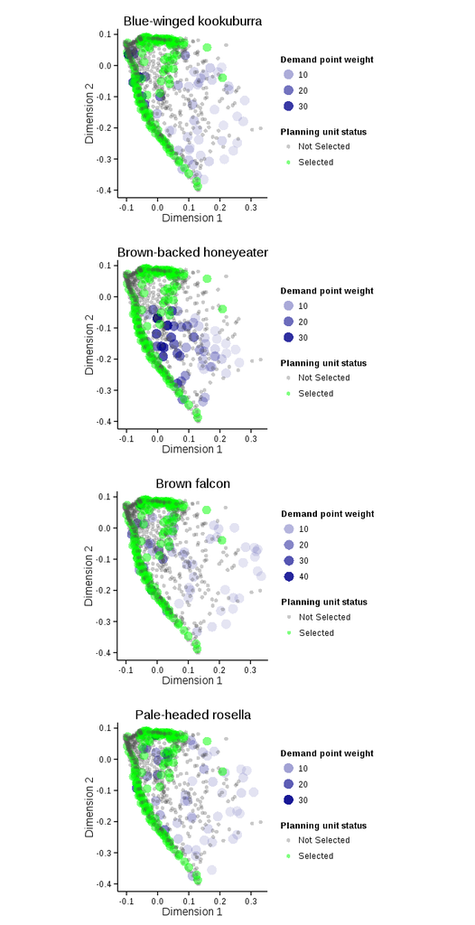

```r
# plot prioritisation in environmental attribute space
p1 <- space.plot(cs_rs_space, 1, 1, main='Blue-winged kookuburra')
p2 <- space.plot(cs_rs_space, 2, 1, main='Brown-backed honeyeater')
p3 <- space.plot(cs_rs_space, 3, 1, main='Brown falcon')
p4 <- space.plot(cs_rs_space, 4, 1, main='Pale-headed rosella')
gridExtra::grid.arrange(p1, p2, p3, p4, ncol=1)
```

```r
# generate vector with Australia's selections
aus_selections <- which(cs_pus$status>0)

# create new object with Australia's network
cs_rs_aus <- update(cs_rs_amount, b=aus_selections)
```

Now, let’s plot the performance metrics for these prioritisations.

```r
# load packages
library(dplyr)
```

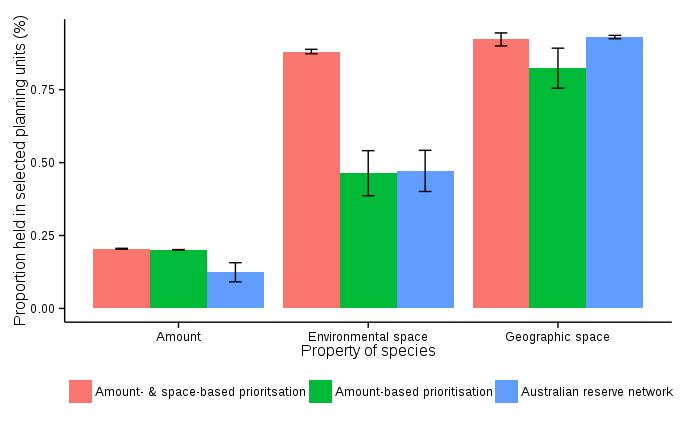

```r
library(ggplot2)

# define standard error function
se=function(x){sd(x,na.rm=TRUE)/sqrt(sum(!is.na(x)))}

# create a table to store the values for the 3 prioritisations
cs_results <- data.frame(
    name=rep(rep(c('Amount-based prioritisation', 'Amount- & space-based prioritsation',
        'Australian reserve network'),each=4),3),
    variable=rep(c('Amount', 'Geographic space', 'Environmental space'), each=12),
    species=colnames(amount.held(cs_rs_amount)),
    value=c(
        amount.held(cs_rs_amount)[1,], amount.held(cs_rs_space)[1,], amount.held(cs_rs_aus)[1,],
        space.held(cs_rs_amount, space=2)[1,], space.held(cs_rs_space, space=2)[1,],
            space.held(cs_rs_aus, space=2)[1,],
        space.held(cs_rs_amount, space=1)[1,], space.held(cs_rs_space, space=1)[1,],
            space.held(cs_rs_aus, space=1)[1,]
    )
) %>% group_by(
    name,
    variable
) %>% summarise(
    mean=mean(value),
    se=se(value)
)

# plot the performance metrics
ggplot(aes(x=variable, y=mean, fill=name), data=cs_results) +
    geom_bar(position=position_dodge(0.9), stat='identity') +
    geom_errorbar(aes(ymin=mean-se, ymax=mean+se), position=position_dodge(0.9), width=0.2) +
    xlab('Property of species') +
    ylab('Proportion held in selected planning units (%)') +
    scale_fill_discrete(
        name=''
    ) +
    theme_classic() +
    theme(legend.position='bottom',legend.direction='horizontal')
```

These results suggest that prioritisations based just on amount-based targets can obtain a moderately representative sample of the species’ geographic distribution and climatic niche. However, a much larger analysis is be required to verify this.

## Conclusions

To maximise the long-term persistence of biodiversity–the stated goal of conservation–decision makers need to identify prioritisations that preserve existing patterns of biodiversity and the processes that support them. To achieve this, conservation planners need a decision support tool that can explicitly accommodate biodiverity patterns and processes. Here, we developed the `rapr` R package to fill this void. By exploring the funciontality of this package using several simulated species, we found that including space-based targets can radically change a prioritisation for the simpliest of species.

## Acknowledgements

JOH is funded by an Australian Postgraduate Award (APA) scholarship. RAF has an Australian Research Council Future Fellowship. This work was supported by the Centre of Excellence for Environmental Decisions (CEED) and the Landscape Ecology and Conservation Group (LEC) at The University of Queensland.

## References

Ball, I., Possingham, H., Watts, M. E. (2009) Marxan and relatives: software for spatial conservation prioritisation. In: *Spatial conservation prioritisation: Quantitative methods & computational tools* (eds A. Moilanen, K. A. Wilson, & H. Possingham) pp. 185–189 Oxford University Press, Oxford, UK.

Beyer, H. L., Dujardin, Y., Watts, M. (2015) Solving conservation planning problems with integer linear programming. *In prep*.

Carvalho, S. B., Brito, J. C., Crespo, E. J., Possingham, H. P. (2011) Incorporating evolutionary processes into conservation planning using species distribution data: a case study with the western mediterranean herpetofauna. *Diversity & Distributions*. **17**, 408–421.

Ciarleglio, M., Wesley Barnes, J., Sarkar, S. (2009) ConsNet: new software for the selection of conservation area networks with spatial and multi-criteria analyses. *Ecography*. **32**, 205–209.

Crandall, K. A., Bininda-Emonds, O. R. P., Mace, G. M., Wayne, R. K. (2000) Considering evolutionary processes in conservation biology. *Trends in Ecology & Evolution*. **15**, 290–295.

Cui, T. T., Ouyang, Y. F., Shen, Z. J. M. (2010) Reliable facility location design under the risk of disruptions. *Operations Research*. **58**, 998–1011.

Faith, D. P. (2003) Environmental diversity (ED) as surrogate information for species-level biodiversity. *Ecography*. **26**, 374–379.

Faith, D. P., Walker, P. A. (1996) Environmental diversity: on the best-possible use of surrogate data for assessing the relative biodiversity of sets of areas. *Biodiversity & Conservation*. **5**, 399–415.

Faith, D., Minchin, P., Belbin, L. (1987) Compositional dissimilarity as a robust measure of ecological distance. *Vegetatio*. **69**, 57–68.

Fernández, E., Landete, M. (2015) Fixed-charge facility location problems. In: *Location science* (eds G. Laporte, S. Nickel, & F. Saldanha da Gama) pp. 47–77 Springer International Publishing.

Hendry, A. P., Lohmann, L. G., Conti, E., Cracraft, J., Crandall, K. A., Faith, D. P., Hauser, C., Joly, C. A., Kogure, K., Larigauderie, A., Magallon, S., Moritz, C., Tillier, S., Zardoya, R., Prieur-Richard, A. H., Walther, B. A., Yahara, T., Donoghue, M. J. (2010) Evolutionary biology in biodiversity science, conservation, and policy: A call to action. *Evolution*. **64**, 1517–1528.

Kleiman, D. G. (1989) Reintroduction of captive mammals for conservation. *BioScience*. **39**, 152–161.

Klein, C., Wilson, K., Watts, M., Stein, J., Berry, S., Carwardine, J., Smith, M. S., Mackey, B., Possingham, H. (2009) Incorporating ecological and evolutionary processes into continental-scale conservation planning. *Ecological applications*. **19**, 206–217.

MacKenzie, D. I., Nichols, J. D., Lachman, G. B., Droege, S., Andrew Royle, J., Langtimm, C. A. (2002) Estimating site occupancy rates when detection probabilities are less than one. *Ecology*. **83**, 2248–2255.

Mahalanobis, P. C. (1936) On the generalized distance in statistics. *Proceedings of the National Institute of Sciences, Calcutta*.

Margules, C. R., Pressey, R. L. (2000) Systematic conservation planning. *Nature*. **405**, 243–253.

McNeely, J. A. (1994) Protected areas for the 21st-century: Working to provide benefits to society. *Biodiversity and Conservation*. **3**, 390–405.

Moilanen, A. (2007) Landscape Zonation, benefit functions and target-based planning: unifying reserve selection strategies. *Biological Conservation*. **134**, 571–579.

Moritz, C. (2002) Strategies to protect biological diversity and the evolutionary processes that sustain it. *Systematic Biology*. **51**, 238–254.

Pressey, R. L., Watts, M. E., Barrett, T. W., Ridges, M. J. (2009) The C-Plan conservation planning system: origins, applications, and possible futures. In: *Spatial conservation prioritisation: Quantitative methods & computational tools* (eds A. Moilanen, K. A. Wilson, & H. Possingham) pp. 211–34 Oxford University Press, Oxford, UK.

Sanderson, E. W., Segan, D. B., Watson, J. E. M. (2015) Global status of and prospects for protection of terrestrial geophysical diversity. *Conservation Biology*. **29**, 649–656.

Sherali, H., Alameddine, A. (1992) A new reformulation-linearization technique for bilinear programming problems. *Journal of Global Optimization*. **2**, 379–410.

Snyder, L. V., Daskin, M. S. (2005) Reliability models for facility location: the expected failure cost case. *Transportation Science*. **39**, 400–416.

Stan Development Team (2015) RStan: The R interface to Stan, Version 2.8.0.